# Part II -

# Engagement of Members with Ford GoBike System in terms of time of day, day of the week.

## by (Ayodele Ayodeji Fortunate)

## Investigation Overview

> In this investigation, I wanted to look at When most trips are taken in terms of time of the day and days of the week in the bike-sharing system covering the greater San Francisco Bay area.

## Dataset Overview

> This dataset includes information about individual rides made in a bike-sharing system covering the greater San Francisco Bay area. The data consists of information regarding 183,412 member's individual trip, including duration in seconds, start time, end time, start station_id and bike share for all trip among others. 8,460 data points were removed from the analysis due to inconsistencies or missing information.

## Distribution of Time of the Day

> Most of the bikes trips were done in the morning time, less were done in the evening, even less in the afternoon with the lest frequent rides happening at night. Same goes for end time of the day. The implies that most of the members engaging with bike-sharing system covering the greater San Francisco Bay starts and ends at same time of the day of which Morning is the most frequent.

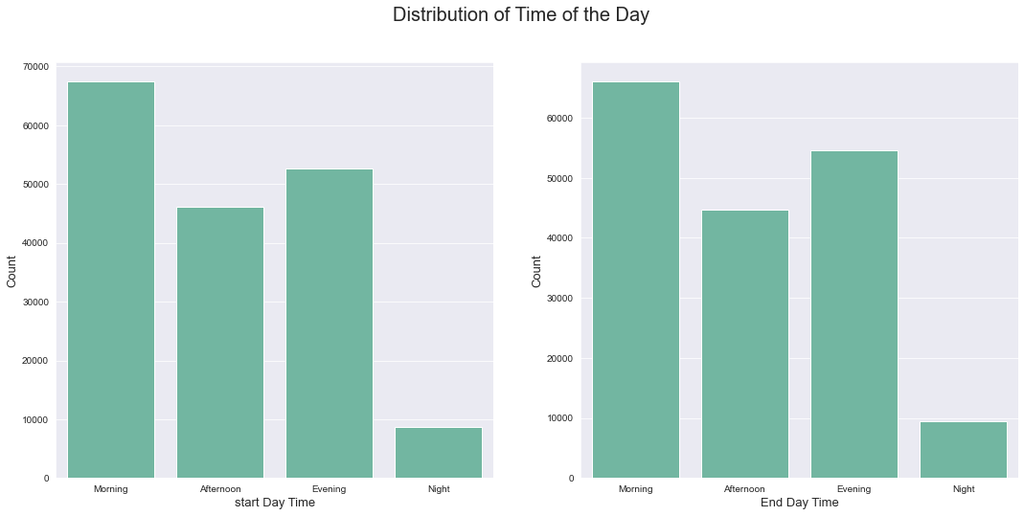

## Distribution of Days of the Week

> There are more start and end trips on Thursdays than any other day of the week. This shows that Thursdays are the most busy day of the week for bike trips in the San Francisco Bay Area.

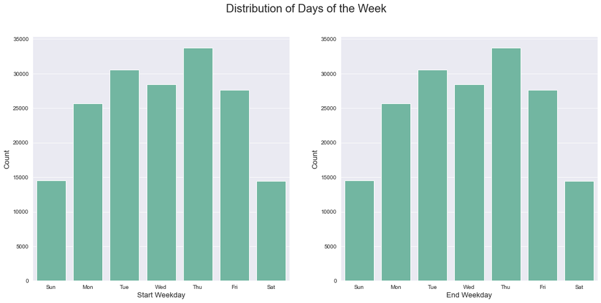

## Distribution of Member's Age

Adult (aged 26 - 60) have the highest engagement in bike trips. They are followed by young adults (aged 18 - 25). Senior Citizens (60 and above) have the least engagement in bike trips.

It is interesting to note that teenagers (aged 13-17) are not familiar with the use of the bike-sharing system in the greater part of San Francisco Bay area

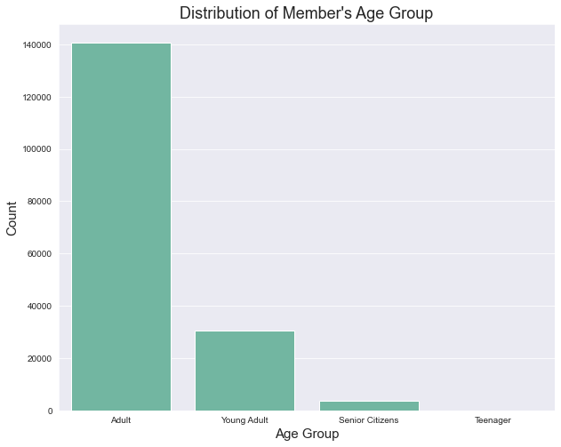

## Member's age groups engaging with bike trips by time of the day

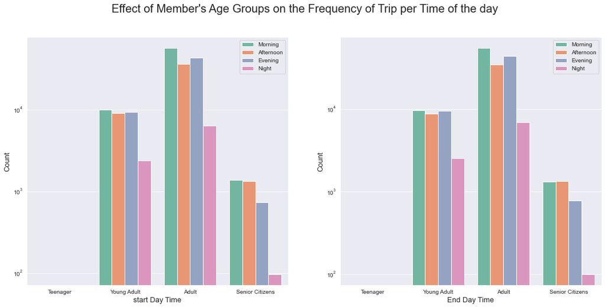

## Member's age groups engaging with bike trips by day of the week

> Also plotting the distribution member age group and day of the week on a logarithmic scale, for the start day of the week, Members engaging with the bike shairing system are matured members and Thursday is the most frequent day of the week in all the specified age groups. This is similar to end week days

[figure not shown]

## User Type engaging with bike trip by time of the day

> Members who are subscribers are the ones really engaging in bike trips by times of the day as there are huge differences observed between the Customers and Subscribers in relationship with their usage of bike sharing systems by time of day. Comparing the effect of user type on the frequency of trips by time of day, Morning time seems to stand out for subscribers while Afternoons seem to be most frequent for customers and applies for both start and end times

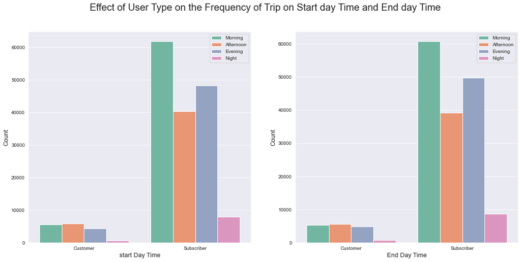

## User Type engaging with bike trip by weekdays

> Interestingly Thursday still seems to stand out in both customers and suscribers For days of the week and this applies for both start and end weekdays.

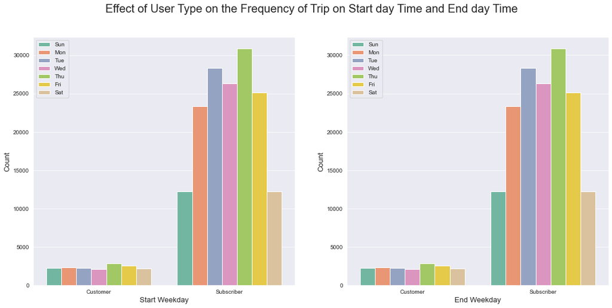

## Member Gender Engaging with Bike Trips by Time of the Day

> Members who are Male members are engaging with bike trips by weekdays than female members. comparing Member Gender with time of the day, morning time appears to be the most frequent time of trips in both start and end time of the day. This is same for days of the week as we would see shortly.

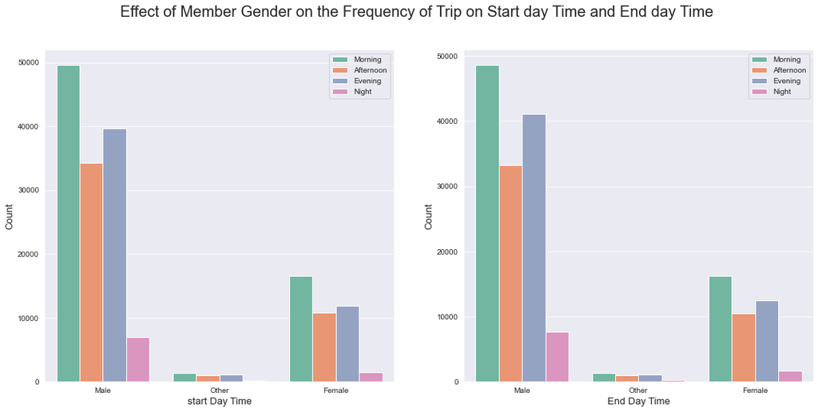

## Member Gender Engaging with Bike Trips by days of the week

> Members who are Male members are the ones really engaging with bike trips by weekdays as there are huge differences observed between the Male members and female members in relationship with their usage of bike sharing system by weekdays.

> comparing the relationship between member gender and start weekday, Thursday still seems to stand out in all the member genger.

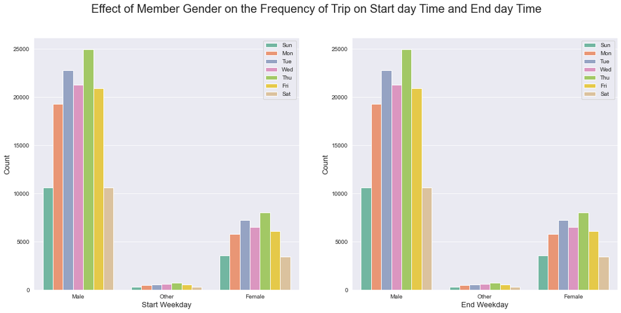

## Effect of the stations on the frequency of trips per days of the week

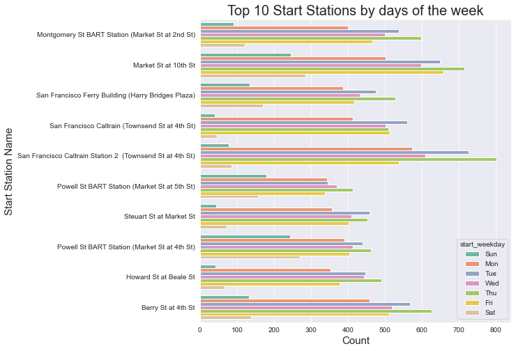

## Duration and User Type by Time of the day

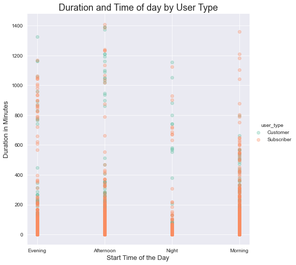

## Duration and User Type by Day of the Week

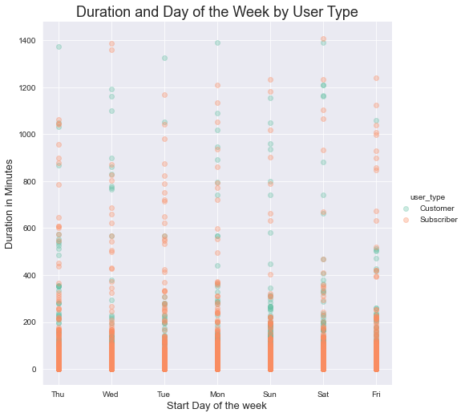

## Duration and Age Groups by Time of the Day

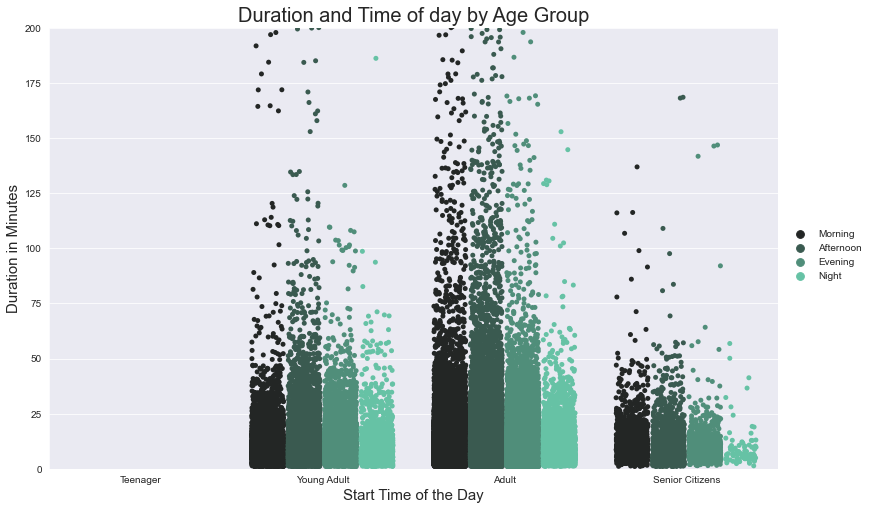

## Duration and Age Groups by Day of the Week

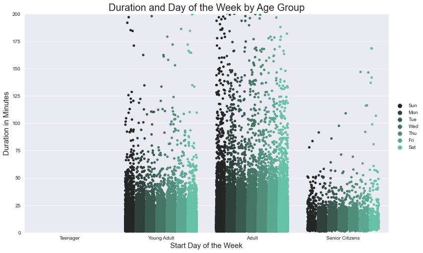

## Duration and Member Gender by Time of the Day

> Compared duration in minutes and time of the day and weekdays by member gender, **Afternoon** time of the day seems to be the most frequent time of the day that members who are Male, Female and Others are engaging with bike sharing system in longer duration in San Francisco Bay area.

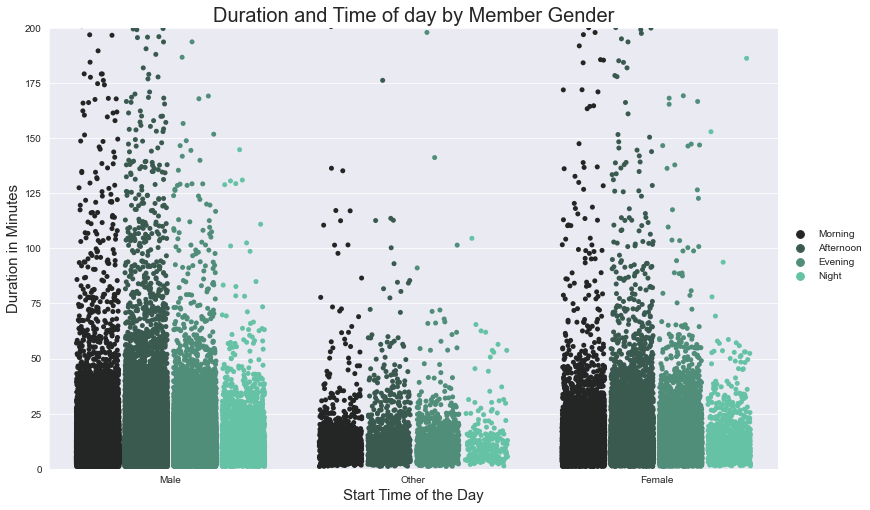

## Duration and Member Gender by Day of the Week

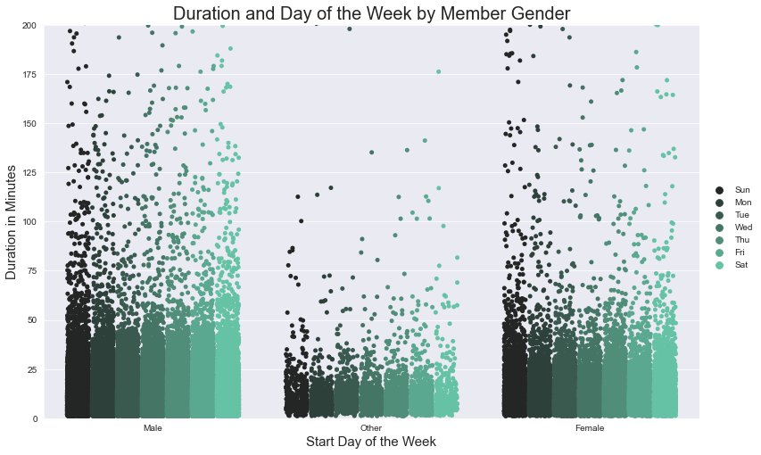